# Máster en Data Science - Machine Learning

# Exploratory Data Analysis (EDA)

Autores: Frida Ibarra y Gema Romero

### **Sobre el Dataset**

El dataset contiene un conjunto de solicitudes de préstamos, donde cada instancia representa a un solicitante individual. El dataset está compuesto por características individuales de cada solicitante, diseñadas para analizar si estas tienen alguna influencia en la probabilidad de enfrentar dificultades para pagar un préstamo.

Según la descripción proporcionada, se garantiza que no se incluye información que comprometa la privacidad de los usuarios.

### **Objetivos del Trabajo:**

Los objetivos principales de esta primera práctica son:

1. Familiarizarse con el dataset y sus características.
2. Realizar un análisis detallado de las variables, evaluando tanto las características individuales como una visión general de las instancias.
3. Comprender la distribución de los datos, las relaciones entre las variables y, con especial atención a su vínculo con la variable objetivo (**Target**), que indica si el solicitante tuvo dificultades para pagar (valor 1) o no (valor 0).
4. Preparar los datos para aplicación de modelos de Machine Learning.
5. Extraer conclusiones sobre la estructura del dataset, identificando sus componentes principales y los patrones revelados durante el análisis exploratorio.

Este enfoque nos permitirá establecer una base sólida para el trabajo con modelos predictivos.

Además, cabe destacar, que el modelo se ejecutará en el momento en que se solicita el préstamo. Por lo tanto, y dada la estructura del dataset, se ha concluido que no hay variables a futuro.

### **Guía del trabajo**

Esta práctica va a estar separada en 3 notebooks, con el fin de optimizar tanto el espacio como el procesamiento de los datos.

#### **Notebook 1 (First_Exploration)**

Centrado en el análisis y en el preprocesamiento de los datos. Va a seguir la siguiente estructura:

1. **Análisis preliminar del los datos.** Tras la inserción de los datos, se va a realizar un análisis preliminar de los mismos con el objetivo de entender el dataset y garantizar su correcta manipulación.
2. **Estudio de la variable objetivo.** Se analizará la variable objetivo, es decir, aquella que se desea explicar a partir de las variables independientes. El enfoque estará en evaluar su tipo, distribución y balance.
3. **Estudio de los valores missing.** Se estudiará la cantidad de valores faltantes y su relación con la variable objetivo. Este análisis ayudará a entender la influencia de las variables con datos faltantes y permitirá tomar decisiones sobre la limpieza del dataset y el manejo de estos valores. Además, se decidirá el trato a posteriori de estos datos.
4. **Análisis de las variables independientes.** Se examinarán las características de las variables independientes, identificando patrones, relaciones y posibles influencias sobre la variable objetivo.

#### **Notebook 2 (Data_Treatment)**

Centrado en el tratamiento de los datos. (Más información en el Notebook 2)

#### **Notebook 3 (Data_Encoding)**

Centrado en la codificación y el escalamiento de los datos. (Más información en el Notebook 3)

### IMPORTACIÓN DE LIBRERÍAS

```python
# Librerías
import os
import pandas as pd
import numpy as np
import openpyxl
import missingno as msno
from colorama import Fore, Style
import seaborn as sns
import matplotlib.pyplot as plt
import sys
import plotly.express as px
```

### FUNCIONES AUXILIARES

```python
sys.path.append('../src/')
import functions_src as fa
sys.path.remove('../src/')
```

### IMPORTACIÓN DEL DATASET

```python
# Obtener la ruta del directorio de trabajo actual
ruta_actual = os.getcwd()
ruta_actual
```

```
'c:\\Users\\gemuc\\OneDrive\\Escritorio\\master5\\aprendizaje\\practica1_EDA\\notebooks'
```

```python
#Importación del dataset
data = '../data/application_data.csv'
df_loans = pd.read_csv(data)
```

```python
df_loans.head()
```

|  | SK_ID_CURR | TARGET | NAME_CONTRACT_TYPE | CODE_GENDER | FLAG_OWN_CAR | FLAG_OWN_REALTY | CNT_CHILDREN | AMT_INCOME_TOTAL | AMT_CREDIT | AMT_ANNUITY | ... | FLAG_DOCUMENT_18 | FLAG_DOCUMENT_19 | FLAG_DOCUMENT_20 | FLAG_DOCUMENT_21 | AMT_REQ_CREDIT_BUREAU_HOUR | AMT_REQ_CREDIT_BUREAU_DAY | AMT_REQ_CREDIT_BUREAU_WEEK | AMT_REQ_CREDIT_BUREAU_MON | AMT_REQ_CREDIT_BUREAU_QRT | AMT_REQ_CREDIT_BUREAU_YEAR |
| --- | --- | --- | --- | --- | --- | --- | --- | --- | --- | --- | --- | --- | --- | --- | --- | --- | --- | --- | --- | --- | --- |
| 0 | 100002 | 1 | Cash loans | M | N | Y | 0 | 202500.0 | 406597.5 | 24700.5 | ... | 0 | 0 | 0 | 0 | 0.0 | 0.0 | 0.0 | 0.0 | 0.0 | 1.0 |
| 1 | 100003 | 0 | Cash loans | F | N | N | 0 | 270000.0 | 1293502.5 | 35698.5 | ... | 0 | 0 | 0 | 0 | 0.0 | 0.0 | 0.0 | 0.0 | 0.0 | 0.0 |
| 2 | 100004 | 0 | Revolving loans | M | Y | Y | 0 | 67500.0 | 135000.0 | 6750.0 | ... | 0 | 0 | 0 | 0 | 0.0 | 0.0 | 0.0 | 0.0 | 0.0 | 0.0 |
| 3 | 100006 | 0 | Cash loans | F | N | Y | 0 | 135000.0 | 312682.5 | 29686.5 | ... | 0 | 0 | 0 | 0 | NaN | NaN | NaN | NaN | NaN | NaN |
| 4 | 100007 | 0 | Cash loans | M | N | Y | 0 | 121500.0 | 513000.0 | 21865.5 | ... | 0 | 0 | 0 | 0 | 0.0 | 0.0 | 0.0 | 0.0 | 0.0 | 0.0 |

5 rows × 122 columns

```python
#También se va a importar el diccionario de datos del dataset
diccionario = '../data/columns_description.xlsx'
data_description = pd.read_excel(diccionario)
data_description
```

|  | Unnamed: 0 | Table | Row | Description | Special |
| --- | --- | --- | --- | --- | --- |
| 0 | 1 | application_data | SK_ID_CURR | ID of loan in our sample | NaN |
| 1 | 2 | application_data | TARGET | Target variable (1 - client with payment diffi... | NaN |
| 2 | 5 | application_data | NAME_CONTRACT_TYPE | Identification if loan is cash or revolving | NaN |
| 3 | 6 | application_data | CODE_GENDER | Gender of the client | NaN |
| 4 | 7 | application_data | FLAG_OWN_CAR | Flag if the client owns a car | NaN |
| ... | ... | ... | ... | ... | ... |
| 155 | 209 | previous_application.csv | DAYS_FIRST_DUE | Relative to application date of current applic... | time only relative to the application |
| 156 | 210 | previous_application.csv | DAYS_LAST_DUE_1ST_VERSION | Relative to application date of current applic... | time only relative to the application |
| 157 | 211 | previous_application.csv | DAYS_LAST_DUE | Relative to application date of current applic... | time only relative to the application |
| 158 | 212 | previous_application.csv | DAYS_TERMINATION | Relative to application date of current applic... | time only relative to the application |
| 159 | 213 | previous_application.csv | NFLAG_INSURED_ON_APPROVAL | Did the client requested insurance during the ... | NaN |

160 rows × 5 columns

### I. ANÁLISIS PRELIMINAR DEL DATASET

```python
# 1 Dimensiones del Dataset
df_loans.shape
print('La dimensión del dataframe está compuesta por', df_loans.shape[0], 'instancias y', df_loans.shape[1], 'variables')
```

```
La dimensión del dataframe está compuesta por 307511 instancias y 122 variables
```

```python
# Número de valores nulos por columna
nulos_por_columna = df_loans.isnull().sum()

# Porcentaje de valores nulos por columna (nulos por columna dividido entre el total de filas)
porcentaje_nulos_por_columna = (nulos_por_columna / df_loans.shape[0]) * 100

# Crear un DataFrame con los resultados
nulos_df = pd.DataFrame({
    'nulos': nulos_por_columna,
    'porcentaje': porcentaje_nulos_por_columna
})

# Mostrar el DataFrame ordenado por el porcentaje de nulos
nulos_df = nulos_df.sort_values(by='porcentaje', ascending=False)
print(nulos_df.to_string())
```

```
                               nulos  porcentaje
COMMONAREA_MEDI               214865   69.872297
COMMONAREA_AVG                214865   69.872297
COMMONAREA_MODE               214865   69.872297
NONLIVINGAPARTMENTS_MODE      213514   69.432963
NONLIVINGAPARTMENTS_AVG       213514   69.432963
NONLIVINGAPARTMENTS_MEDI      213514   69.432963
FONDKAPREMONT_MODE            210295   68.386172
LIVINGAPARTMENTS_MODE         210199   68.354953
LIVINGAPARTMENTS_AVG          210199   68.354953
LIVINGAPARTMENTS_MEDI         210199   68.354953
FLOORSMIN_AVG                 208642   67.848630
FLOORSMIN_MODE                208642   67.848630
FLOORSMIN_MEDI                208642   67.848630
YEARS_BUILD_MEDI              204488   66.497784
YEARS_BUILD_MODE              204488   66.497784
YEARS_BUILD_AVG               204488   66.497784
OWN_CAR_AGE                   202929   65.990810
LANDAREA_MEDI                 182590   59.376738
LANDAREA_MODE                 182590   59.376738
LANDAREA_AVG                  182590   59.376738
BASEMENTAREA_MEDI             179943   58.515956
BASEMENTAREA_AVG              179943   58.515956
BASEMENTAREA_MODE             179943   58.515956
EXT_SOURCE_1                  173378   56.381073
NONLIVINGAREA_MODE            169682   55.179164
NONLIVINGAREA_AVG             169682   55.179164
NONLIVINGAREA_MEDI            169682   55.179164
ELEVATORS_MEDI                163891   53.295980
ELEVATORS_AVG                 163891   53.295980
ELEVATORS_MODE                163891   53.295980
WALLSMATERIAL_MODE            156341   50.840783
APARTMENTS_MEDI               156061   50.749729
APARTMENTS_AVG                156061   50.749729
APARTMENTS_MODE               156061   50.749729
ENTRANCES_MEDI                154828   50.348768
ENTRANCES_AVG                 154828   50.348768
ENTRANCES_MODE                154828   50.348768
LIVINGAREA_AVG                154350   50.193326
LIVINGAREA_MODE               154350   50.193326
```

[output cut: 68 more lines]

```
FLAG_CONT_MOBILE                   0    0.000000
ORGANIZATION_TYPE                  0    0.000000
FLAG_WORK_PHONE                    0    0.000000
FLAG_EMP_PHONE                     0    0.000000
FLAG_MOBIL                         0    0.000000
DAYS_ID_PUBLISH                    0    0.000000
DAYS_REGISTRATION                  0    0.000000
DAYS_EMPLOYED                      0    0.000000
DAYS_BIRTH                         0    0.000000
REGION_POPULATION_RELATIVE         0    0.000000
NAME_HOUSING_TYPE                  0    0.000000
NAME_FAMILY_STATUS                 0    0.000000
NAME_EDUCATION_TYPE                0    0.000000
NAME_INCOME_TYPE                   0    0.000000
SK_ID_CURR                         0    0.000000
```

```python
df_datatypes = pd.DataFrame(df_loans
                            .dtypes.value_counts(normalize=True)
                            .mul(100).rename('percent').reset_index()
                            .round(0)
)
print('El dataframe cuenta con los siguientes tipos de datos (%): ')
df_datatypes
```

```
El dataframe cuenta con los siguientes tipos de datos (%):
```

|  | index | percent |
| --- | --- | --- |
| 0 | float64 | 53.0 |
| 1 | int64 | 34.0 |
| 2 | object | 13.0 |

La distribución de los tipos de variables también es un factor a tener muy en cuenta, a priori el tipo de variable que predomina es float con un 53% de los datos, sin embargo se deberá profundizar en el analisis de dichas variables para derterminar si dicho porcentaje refleja la realidad de los datos.

```python
# Seleccionar las columnas categóricas
categorical_var = df_loans.select_dtypes(include=['object', 'category'])

# Mostrar los tipos de datos de las columnas categóricas
print(categorical_var.dtypes)
```

```
NAME_CONTRACT_TYPE            object
CODE_GENDER                   object
FLAG_OWN_CAR                  object
FLAG_OWN_REALTY               object
NAME_TYPE_SUITE               object
NAME_INCOME_TYPE              object
NAME_EDUCATION_TYPE           object
NAME_FAMILY_STATUS            object
NAME_HOUSING_TYPE             object
OCCUPATION_TYPE               object
WEEKDAY_APPR_PROCESS_START    object
ORGANIZATION_TYPE             object
FONDKAPREMONT_MODE            object
HOUSETYPE_MODE                object
WALLSMATERIAL_MODE            object
EMERGENCYSTATE_MODE           object
dtype: object
```

Esta información obtenida no es del todo confiable ya que pueden haber variales categóricas codificadas lo que implicaría que no aparecen en el listado obtenido

Se puede ver que hay algunas variables con valores booleanos y también csategóricos, lo que es importante destacar ya que a pesar de que figuren con un número el tratamiento que reciben es distinto debido a su naturaleza.

```python
duplicated_columns = df_loans.columns[df_loans.columns.duplicated()].tolist()
duplicated_columns
```

```
[]
```

Se puede confirmar que no existen columnas duplicadas

### II. ESTUDIO DE LA VARIABLE OBJETIVO ('TARGET')

La variable objetivo es la variable Target

0: Cliente SIN dificultades de pago  
1: Cliente CON dificultades de pago

Se va a llevar a cabo un estudio de la distribución de los clientes dentro de la variable objetivo.

```python
# Crear el DataFrame de la variable TARGET con el conteo de valores
target_df_count = df_loans['TARGET'].value_counts().reset_index()

#Crea el dataframe de la variable TARGET y su distribución en porcentaje
target_df_percent = df_loans['TARGET']\
    .value_counts(normalize=True)\
    .mul(100).rename('percent').reset_index()\
    .round(2)

#Mergear los dataframes
target_df_merge = pd.merge(target_df_count, target_df_percent, on='TARGET', how='inner')
target_df_merge
```

|  | TARGET | count | percent |
| --- | --- | --- | --- |
| 0 | 0 | 282686 | 91.93 |
| 1 | 1 | 24825 | 8.07 |

Se va a proceder a graficar la tabla obtenida para mayor claridad

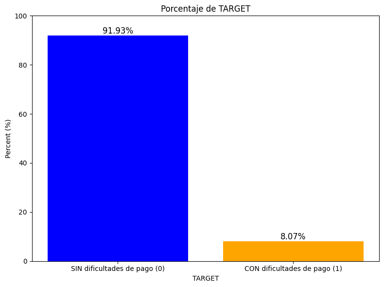

```python
fig, ax = plt.subplots(figsize = (8,6)) #cuadrícula

# Crear gráfico de barras
bar_plot= plt.bar(target_df_merge['TARGET'], target_df_merge['percent'], color=['blue', 'orange'])

#ajustar el limite superior del eje y
plt.ylim(0, 100)

# Agregar etiquetas con el porcentaje de cada valor encima de las barras
for bar in bar_plot:
    yvalue = bar.get_height()  # Obtener la altura de cada barra
    plt.text(bar.get_x() + bar.get_width() / 2, yvalue + 0.02, f'{yvalue:.2f}%',
             ha='center', va='bottom', fontsize=12)


# Agregar etiquetas y título al gráfico
plt.xlabel('TARGET')
ax.set_xticks([0,1], labels=['SIN dificultades de pago (0)', 'CON dificultades de pago (1)'])
plt.ylabel('Percent (%)')
plt.title('Porcentaje de TARGET')
plt.xticks(target_df_merge['TARGET'])  # Asegura que las etiquetas del eje X sean correctas
plt.tight_layout()
plt.show()
```

*Conclusiones*:

En este caso un 91% de los clientes NO tuvieron alguna dificultad a la hora de hacer frente a los pagos correspondientes, mientras que un 8,07% de los clientes tuvieron retrasos en el pago de sus respectivos adeudos.

Por ello se puede afirmar que la muestra se encuentra **DESBALANCEADA**

```python
#Variable TARGET a categorica
df_loans['TARGET'] = df_loans['TARGET'].astype('category')
```

### III. DATOS MISSING (NA)

Antes de abordar los valores missing, es fundamental analizar su contribución a la muestra, en particular a la variable objetivo. Esto implica considerar que algunas variables pueden tener poca relevancia, otras podrían aportar información valiosa, o incluso reflejar datos que los usuarios decidieron no proporcionar. Por este motivo, es crucial distinguir entre estos casos para garantizar que no se comprometa la calidad de los datos durante el análisis. Este enfoque permitirá tomar decisiones más informadas al tratar los valores ausentes.

Con el objetivo de evaluar la completitud de los datos, se ha generado una gráfica para cada variable. Estas gráficas permiten identificar con claridad cuáles concentran un mayor porcentaje de valores NA, facilitando el análisis y la toma de decisiones respecto a su manipulación.

```
AMT_ANNUITY                       12
AMT_GOODS_PRICE                  278
NAME_TYPE_SUITE                 1292
OWN_CAR_AGE                   202929
OCCUPATION_TYPE                96391
                               ...
AMT_REQ_CREDIT_BUREAU_DAY      41519
AMT_REQ_CREDIT_BUREAU_WEEK     41519
AMT_REQ_CREDIT_BUREAU_MON      41519
AMT_REQ_CREDIT_BUREAU_QRT      41519
AMT_REQ_CREDIT_BUREAU_YEAR     41519
Length: 67, dtype: int64
```

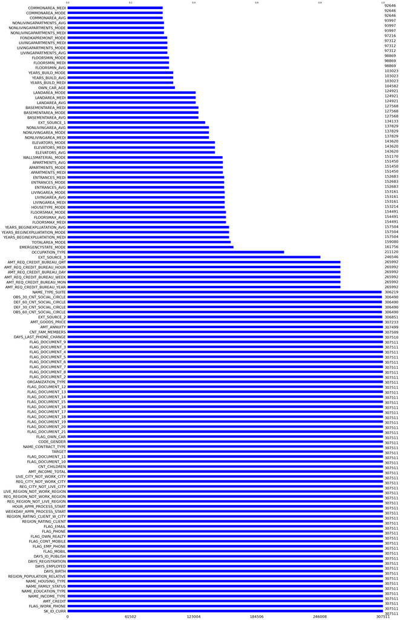

```python
#Para visualizar de manera eficaz las variables con valores faltantes (completitud de los datos):
msno.bar(df_loans, filter="Top", sort = 'descending', color = 'blue')

#Cantidad de valores missing
missing_df = df_loans.loc[:, df_loans.isna().any()].isna().sum()
missing_df
```

```python
#relación entre los valores nulos y la variable TARGET
resultados=fa.relacion_nulos_target(df_loans)
print(resultados)
```

```
{'AMT_ANNUITY': TARGET
0    0.004245
1    0.000000
Name: AMT_ANNUITY, dtype: float64, 'AMT_GOODS_PRICE': TARGET
0    0.090914
1    0.084592
Name: AMT_GOODS_PRICE, dtype: float64, 'NAME_TYPE_SUITE': TARGET
0    0.432282
1    0.281974
Name: NAME_TYPE_SUITE, dtype: float64, 'OWN_CAR_AGE': TARGET
0    65.684187
1    69.482377
Name: OWN_CAR_AGE, dtype: float64, 'OCCUPATION_TYPE': TARGET
0    31.877419
1    25.289023
Name: OCCUPATION_TYPE, dtype: float64, 'CNT_FAM_MEMBERS': TARGET
0    0.000707
1    0.000000
Name: CNT_FAM_MEMBERS, dtype: float64, 'EXT_SOURCE_1': TARGET
0    56.107129
1    59.500504
Name: EXT_SOURCE_1, dtype: float64, 'EXT_SOURCE_2': TARGET
0    0.215080
1    0.209466
Name: EXT_SOURCE_2, dtype: float64, 'EXT_SOURCE_3': TARGET
0    19.558096
1    22.868077
Name: EXT_SOURCE_3, dtype: float64, 'APARTMENTS_AVG': TARGET
0    50.153173
1    57.542800
Name: APARTMENTS_AVG, dtype: float64, 'BASEMENTAREA_AVG': TARGET
0    57.981294
1    64.604230
Name: BASEMENTAREA_AVG, dtype: float64, 'YEARS_BEGINEXPLUATATION_AVG': TARGET
0    48.180313
1    55.621349
Name: YEARS_BEGINEXPLUATATION_AVG, dtype: float64, 'YEARS_BUILD_AVG': TARGET
0    66.058100
1    71.504532
Name: YEARS_BUILD_AVG, dtype: float64, 'COMMONAREA_AVG': TARGET
```

[output cut: 147 more lines]

```
0    13.169029
1    17.289023
Name: AMT_REQ_CREDIT_BUREAU_DAY, dtype: float64, 'AMT_REQ_CREDIT_BUREAU_WEEK': TARGET
0    13.169029
1    17.289023
Name: AMT_REQ_CREDIT_BUREAU_WEEK, dtype: float64, 'AMT_REQ_CREDIT_BUREAU_MON': TARGET
0    13.169029
1    17.289023
Name: AMT_REQ_CREDIT_BUREAU_MON, dtype: float64, 'AMT_REQ_CREDIT_BUREAU_QRT': TARGET
0    13.169029
1    17.289023
Name: AMT_REQ_CREDIT_BUREAU_QRT, dtype: float64, 'AMT_REQ_CREDIT_BUREAU_YEAR': TARGET
0    13.169029
1    17.289023
Name: AMT_REQ_CREDIT_BUREAU_YEAR, dtype: float64}
```

### IV. ANÁLISIS DE LAS VARIABLES INDEPENDIENTES

```python
# Aplicar la conversión a todas las columnas que solo tengan 0s y 1s
df_loans = df_loans.apply(lambda x: x.astype(bool).astype(int) if x.isin([0, 1]).all() else x)
```

```python
# Ejemplo de uso con un DataFrame llamado df
fa.data_summary(df_loans)
```

```
SK_ID_CURR (numeric) : (Type: int64) Range = [100002.00 to 456255.00], Mean = 278180.52

TARGET (boolean) : (Type: int32) Unique: [1, 0]

NAME_CONTRACT_TYPE (categoric) : (Type: object) Values: ['Cash loans' 'Revolving loans']

CODE_GENDER (categoric) : (Type: object) Values: ['M' 'F' 'XNA']

FLAG_OWN_CAR (categoric) : (Type: object) Values: ['N' 'Y']

FLAG_OWN_REALTY (categoric) : (Type: object) Values: ['Y' 'N']

CNT_CHILDREN (numeric) : (Type: int64) Range = [0.00 to 19.00], Mean = 0.42

AMT_INCOME_TOTAL (numeric) : (Type: float64) Range = [25650.00 to 117000000.00], Mean = 168797.92

AMT_CREDIT (numeric) : (Type: float64) Range = [45000.00 to 4050000.00], Mean = 599026.00

AMT_ANNUITY (numeric) : (Type: float64) Range = [1615.50 to 258025.50], Mean = 27108.57

AMT_GOODS_PRICE (numeric) : (Type: float64) Range = [40500.00 to 4050000.00], Mean = 538396.21

NAME_TYPE_SUITE (categoric) : (Type: object) Values: ['Unaccompanied' 'Family' 'Spouse, partner' 'Children' 'Other_A'] ...

NAME_INCOME_TYPE (categoric) : (Type: object) Values: ['Working' 'State servant' 'Commercial associate' 'Pensioner' 'Unemployed'] ...

NAME_EDUCATION_TYPE (categoric) : (Type: object) Values: ['Secondary / secondary special' 'Higher education' 'Incomplete higher'
 'Lower secondary' 'Academic degree']

NAME_FAMILY_STATUS (categoric) : (Type: object) Values: ['Single / not married' 'Married' 'Civil marriage' 'Widow' 'Separated'] ...

NAME_HOUSING_TYPE (categoric) : (Type: object) Values: ['House / apartment' 'Rented apartment' 'With parents'
 'Municipal apartment' 'Office apartment'] ...

REGION_POPULATION_RELATIVE (numeric) : (Type: float64) Range = [0.00 to 0.07], Mean = 0.02

DAYS_BIRTH (numeric) : (Type: int64) Range = [-25229.00 to -7489.00], Mean = -16037.00

DAYS_EMPLOYED (numeric) : (Type: int64) Range = [-17912.00 to 365243.00], Mean = 63815.05

```

[output cut: 191 more lines]

```
FLAG_DOCUMENT_20 (boolean) : (Type: int32) Unique: [0, 1]

FLAG_DOCUMENT_21 (boolean) : (Type: int32) Unique: [0, 1]

AMT_REQ_CREDIT_BUREAU_HOUR (numeric) : (Type: float64) Range = [0.00 to 4.00], Mean = 0.01

AMT_REQ_CREDIT_BUREAU_DAY (numeric) : (Type: float64) Range = [0.00 to 9.00], Mean = 0.01

AMT_REQ_CREDIT_BUREAU_WEEK (numeric) : (Type: float64) Range = [0.00 to 8.00], Mean = 0.03

AMT_REQ_CREDIT_BUREAU_MON (numeric) : (Type: float64) Range = [0.00 to 27.00], Mean = 0.27

AMT_REQ_CREDIT_BUREAU_QRT (numeric) : (Type: float64) Range = [0.00 to 261.00], Mean = 0.27

AMT_REQ_CREDIT_BUREAU_YEAR (numeric) : (Type: float64) Range = [0.00 to 25.00], Mean = 1.90
```

```python
df_loans.select_dtypes('float')
```

|  | AMT_INCOME_TOTAL | AMT_CREDIT | AMT_ANNUITY | AMT_GOODS_PRICE | REGION_POPULATION_RELATIVE | DAYS_REGISTRATION | OWN_CAR_AGE | CNT_FAM_MEMBERS | EXT_SOURCE_1 | EXT_SOURCE_2 | ... | DEF_30_CNT_SOCIAL_CIRCLE | OBS_60_CNT_SOCIAL_CIRCLE | DEF_60_CNT_SOCIAL_CIRCLE | DAYS_LAST_PHONE_CHANGE | AMT_REQ_CREDIT_BUREAU_HOUR | AMT_REQ_CREDIT_BUREAU_DAY | AMT_REQ_CREDIT_BUREAU_WEEK | AMT_REQ_CREDIT_BUREAU_MON | AMT_REQ_CREDIT_BUREAU_QRT | AMT_REQ_CREDIT_BUREAU_YEAR |
| --- | --- | --- | --- | --- | --- | --- | --- | --- | --- | --- | --- | --- | --- | --- | --- | --- | --- | --- | --- | --- | --- |
| 0 | 202500.0 | 406597.5 | 24700.5 | 351000.0 | 0.018801 | -3648.0 | NaN | 1.0 | 0.083037 | 0.262949 | ... | 2.0 | 2.0 | 2.0 | -1134.0 | 0.0 | 0.0 | 0.0 | 0.0 | 0.0 | 1.0 |
| 1 | 270000.0 | 1293502.5 | 35698.5 | 1129500.0 | 0.003541 | -1186.0 | NaN | 2.0 | 0.311267 | 0.622246 | ... | 0.0 | 1.0 | 0.0 | -828.0 | 0.0 | 0.0 | 0.0 | 0.0 | 0.0 | 0.0 |
| 2 | 67500.0 | 135000.0 | 6750.0 | 135000.0 | 0.010032 | -4260.0 | 26.0 | 1.0 | NaN | 0.555912 | ... | 0.0 | 0.0 | 0.0 | -815.0 | 0.0 | 0.0 | 0.0 | 0.0 | 0.0 | 0.0 |
| 3 | 135000.0 | 312682.5 | 29686.5 | 297000.0 | 0.008019 | -9833.0 | NaN | 2.0 | NaN | 0.650442 | ... | 0.0 | 2.0 | 0.0 | -617.0 | NaN | NaN | NaN | NaN | NaN | NaN |
| 4 | 121500.0 | 513000.0 | 21865.5 | 513000.0 | 0.028663 | -4311.0 | NaN | 1.0 | NaN | 0.322738 | ... | 0.0 | 0.0 | 0.0 | -1106.0 | 0.0 | 0.0 | 0.0 | 0.0 | 0.0 | 0.0 |
| ... | ... | ... | ... | ... | ... | ... | ... | ... | ... | ... | ... | ... | ... | ... | ... | ... | ... | ... | ... | ... | ... |
| 307506 | 157500.0 | 254700.0 | 27558.0 | 225000.0 | 0.032561 | -8456.0 | NaN | 1.0 | 0.145570 | 0.681632 | ... | 0.0 | 0.0 | 0.0 | -273.0 | NaN | NaN | NaN | NaN | NaN | NaN |
| 307507 | 72000.0 | 269550.0 | 12001.5 | 225000.0 | 0.025164 | -4388.0 | NaN | 1.0 | NaN | 0.115992 | ... | 0.0 | 0.0 | 0.0 | 0.0 | NaN | NaN | NaN | NaN | NaN | NaN |
| 307508 | 153000.0 | 677664.0 | 29979.0 | 585000.0 | 0.005002 | -6737.0 | NaN | 1.0 | 0.744026 | 0.535722 | ... | 0.0 | 6.0 | 0.0 | -1909.0 | 1.0 | 0.0 | 0.0 | 1.0 | 0.0 | 1.0 |
| 307509 | 171000.0 | 370107.0 | 20205.0 | 319500.0 | 0.005313 | -2562.0 | NaN | 2.0 | NaN | 0.514163 | ... | 0.0 | 0.0 | 0.0 | -322.0 | 0.0 | 0.0 | 0.0 | 0.0 | 0.0 | 0.0 |
| 307510 | 157500.0 | 675000.0 | 49117.5 | 675000.0 | 0.046220 | -5128.0 | NaN | 2.0 | 0.734460 | 0.708569 | ... | 0.0 | 0.0 | 0.0 | -787.0 | 0.0 | 0.0 | 0.0 | 2.0 | 0.0 | 1.0 |

307511 rows × 65 columns

Se puede observar que hay una gran variedad de tipos de datos para las variables de tipo numñericas sobre todo ya que en algunos de los casos se encnentran codificadas lo que significa que realmente son de tipo categóricas a pesar de figurar cono numérica

```python
# Convertir la columna de float a object, conservando los NA
df_loans["CNT_FAM_MEMBERS"] = df_loans["CNT_FAM_MEMBERS"].astype('object')
```

Se ha detectado que la columna NT_FAM_MEMBERS contiene valores que están considerados apriori como de tipo numérica cuando realmente es una variable categórica

```python
col_bool, col_cat, col_num = fa.categorizar_columnas(df_loans)
```

```python
types_count = pd.DataFrame([['Boolean',len(col_bool)]
                                ,['Categoric',len(col_cat)]
                                ,['Numeric',len(col_num)]]
                               , columns=['Var_type','Count'])
types_count
```

|  | Var_type | Count |
| --- | --- | --- |
| 0 | Boolean | 0 |
| 1 | Categoric | 17 |
| 2 | Numeric | 72 |

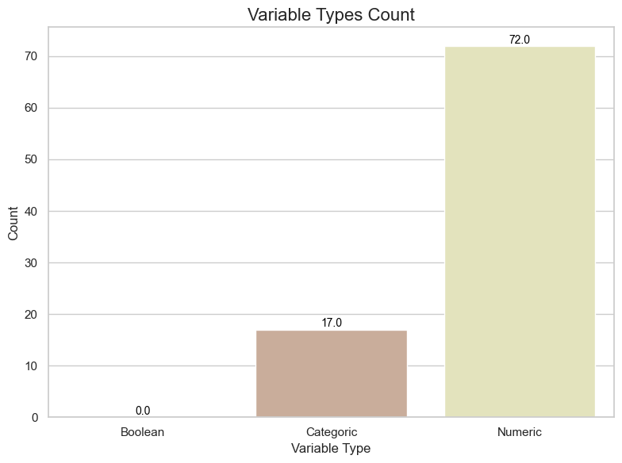

```python
# Configurar el estilo de Seaborn
sns.set(style="whitegrid")

# Crear el gráfico de barras con Seaborn
plt.figure(figsize=(8, 6))
ax = sns.barplot(x='Var_type', y='Count', data=types_count, palette="pink")

# Añadir etiquetas con el total encima de cada barra
for bar in ax.patches:  # `ax.patches` contiene las barras del gráfico
    total = bar.get_height()  # Obtener la altura de la barra
    ax.text(
        bar.get_x() + bar.get_width() / 2,  # Posición en X centrada
        total + 0.5,                        # Posición en Y un poco arriba
        f'{total}',                         # Texto con el total
        ha='center', fontsize=10, color='black'
    )

# Añadir títulos y etiquetas
plt.title('Variable Types Count', fontsize=16)
plt.xlabel('Variable Type', fontsize=12)
plt.ylabel('Count', fontsize=12)

# Mostrar el gráfico
plt.tight_layout()
plt.show()
```

En esta tabla se puede ver que hay claramente un número superior de variables de tipo Numérico seguido de Categórico y por último de variables buleanas

```python
for col in col_bool:  # columnas_bool es la lista con nombres de columnas booleanas
    print(f"Frecuencia relativa de {col}:")
    print(df_loans[col].value_counts(normalize=True))
    print()  #
```

```python
cat_vars = df_loans[col_cat].dtypes.reset_index().rename(columns={'index':'Var',0:'dtype'})
cat_vars
```

|  | Var | dtype |
| --- | --- | --- |
| 0 | NAME_CONTRACT_TYPE | object |
| 1 | CODE_GENDER | object |
| 2 | FLAG_OWN_CAR | object |
| 3 | FLAG_OWN_REALTY | object |
| 4 | NAME_TYPE_SUITE | object |
| 5 | NAME_INCOME_TYPE | object |
| 6 | NAME_EDUCATION_TYPE | object |
| 7 | NAME_FAMILY_STATUS | object |
| 8 | NAME_HOUSING_TYPE | object |
| 9 | OCCUPATION_TYPE | object |
| 10 | CNT_FAM_MEMBERS | object |
| 11 | WEEKDAY_APPR_PROCESS_START | object |
| 12 | ORGANIZATION_TYPE | object |
| 13 | FONDKAPREMONT_MODE | object |
| 14 | HOUSETYPE_MODE | object |
| 15 | WALLSMATERIAL_MODE | object |
| 16 | EMERGENCYSTATE_MODE | object |

```python
cat_vars_count = cat_vars.dtype.value_counts().sort_values().reset_index()
cat_vars_count
```

|  | dtype | count |
| --- | --- | --- |
| 0 | object | 17 |

```python
num_vars=df_loans[col_num].dtypes.reset_index().rename(columns={'index':'Var',0:'dtype'})
num_vars
```

|  | Var | dtype |
| --- | --- | --- |
| 0 | SK_ID_CURR | int64 |
| 1 | CNT_CHILDREN | int64 |
| 2 | AMT_INCOME_TOTAL | float64 |
| 3 | AMT_CREDIT | float64 |
| 4 | AMT_ANNUITY | float64 |
| ... | ... | ... |
| 67 | AMT_REQ_CREDIT_BUREAU_DAY | float64 |
| 68 | AMT_REQ_CREDIT_BUREAU_WEEK | float64 |
| 69 | AMT_REQ_CREDIT_BUREAU_MON | float64 |
| 70 | AMT_REQ_CREDIT_BUREAU_QRT | float64 |
| 71 | AMT_REQ_CREDIT_BUREAU_YEAR | float64 |

72 rows × 2 columns

```python
num_vars_count = num_vars.dtype.value_counts().sort_values().reset_index().rename(columns={'dtype':'type','count':'count_num'})
num_vars_count
```

|  | type | count_num |
| --- | --- | --- |
| 0 | int64 | 8 |
| 1 | float64 | 64 |

La tabla muestra que la mayoría de las variables numéricas son de tipo float64 (64), lo que indica que representan datos continuos con decimales. Solo 8 variables son de tipo int64, sugiriendo que algunas variables numéricas son discretas, como contadores o índices. Esto refuerza la idea de que el análisis debe centrarse en datos continuos, pero también considerar las transformaciones necesarias para las variables categóricas y booleanas. En general, la estructura numérica del dataset es principalmente continua.

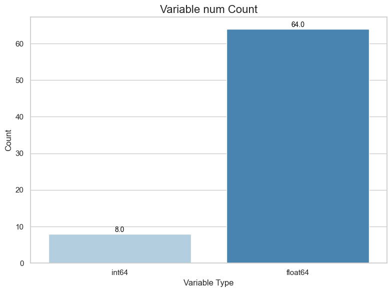

```python
# Configurar el estilo de Seaborn
sns.set(style="whitegrid")

# Crear el gráfico de barras con Seaborn
plt.figure(figsize=(8, 6))
ax = sns.barplot(x='type', y='count_num', data=num_vars_count, palette="Blues")

# Añadir etiquetas con el total encima de cada barra
for bar in ax.patches:  # `ax.patches` contiene las barras del gráfico
    total = bar.get_height()  # Obtener la altura de la barra
    ax.text(
        bar.get_x() + bar.get_width() / 2,  # Posición en X centrada
        total + 0.5,                        # Posición en Y un poco arriba
        f'{total}',                         # Texto con el total
        ha='center', fontsize=10, color='black'
    )

# Añadir títulos y etiquetas
plt.title('Variable num Count', fontsize=16)
plt.xlabel('Variable Type', fontsize=12)
plt.ylabel('Count', fontsize=12)

# Mostrar el gráfico
plt.tight_layout()
plt.show()
```

La tabla muestra que la mayoría de las variables numéricas son de tipo float64 (64), lo que indica que representan datos continuos NO enteros. Solo 8 variables son de tipo int64, sugiriendo que algunas variables numéricas son discretas, como contadores o índices. Esto refuerza la idea de que el análisis debe centrarse en datos continuos, pero también considerar las transformaciones necesarias para las variables categóricas y booleanas. En general, la estructura del dataset es principalmente continua.

### FIN NOTEBOOK 1

```python
df_loans.to_csv('../data/Processing_data/application_data(1).csv')
```